# Section 7: Introduction to Statistics

Calculus Lecture Series

2026-10-13

# Learning Objectives

1. Understand what statistics is and the characteristics of statistical data
2. Distinguish descriptive statistics from inferential statistics
3. Understand the four different tools used in descriptive statistics
4. Understand the 68, 95, and 99.7 rules
5. Using Excel for descriptive statistics

R skills

1. Use R to fetch data
2. Use R to describe data

# 7.1 Introduction to statistics

**Definition of Statistics**

Statistics is the study of collecting, analyzing, and interpreting data. In today’s information society, data are everywhere. Statistics is a tool for transforming data into useful information.

## 7.1.1 Sources of data

- Primary data: data collected by the researcher.
- Secondary data: data collected by someone else.

**Using Google Form to collect primary data**

- Step 1 Register for a Google account
- Step 2 Add a Google Form in Google Drive
- Step 3 Design the survey questions by editing the Google Form
- Step 4 Preview the Google Form and the Google Sheet for a pilot run
- Step 5 Distribute the final Google Form via email, a link, or a QR code

### [Use Google Form to Collect Primary Data](https://www.youtube.com/embed/JIbWFGE0mcg?si=exZSQcWGqac7at_Y)

[video not shown]

### Use R to fetch secondary data

```r
library(tidyquant)
library(tidyverse)

stocks <- c("AMT","CAT","CI","CSCO","MA")


stock_data <- tq_get(stocks,
                     from = "2015-01-01",
                     to = Sys.Date(),
                     get = "stock.prices") %>%
  group_by(symbol) %>%
  tq_transmute(select = adjusted,
               mutate_fun = to.monthly,
               indexAt = "firstof",
               col_rename = "monthly_price")

head(stock_data)
```

```
## # A tibble: 6 × 3
## # Groups:   symbol [1]
##   symbol date       monthly_price
##   <chr>  <date>             <dbl>
## 1 AMT    2015-01-01          72.2
## 2 AMT    2015-02-01          73.8
## 3 AMT    2015-03-01          70.1
## 4 AMT    2015-04-01          70.7
## 5 AMT    2015-05-01          69.4
## 6 AMT    2015-06-01          70.1
```

## 7.1.2 Components of a data set

As a result of a data collection process we obtain a data set. A typical data set looks like a data table as follows.

```r
knitr::include_url(url = "https://docs.google.com/spreadsheets/d/1IJoAcrXvJdzp0EicTiTyfOakPhj__W3S/edit?usp=drive_link&ouid=102286783521575958009&rtpof=true&sd=true", height = "450px")
```

[interactive chart not shown]

**Four components of a data set: Elements, variables, observations, and size**

- **Element**: the basic unit on which we measure characteristics and collect data. The set of all elements is called the population. A census is a survey that collects data for the entire population. Data collected for a subset of the population is referred to as sample data.
- **Variables**: describe common characteristics of elements.
- **Observation**: the record of the values measured on one element
- **Size**: the total number of observations in the data set. It is also the total number of elements in the data set. Often, we call a data set a sample data set and the size of the data set the sample size.

## 7.1.3 Variable types and scales of measurement

**Types of statistical variables** - categorical - numerical

**Scale of measurement** - For categorical variables: nominal or ordinal - For numerical variables: discrete or continuous

Examples:

- Gender is a nominal categorical variable despite that it is coded in numbers 1 and 2
- Job satisfaction score is an ordinal categorical variable because we know 2 is above 1 and 3 is above 2, etc. But we do not have 1 + 1 = 2.
- Age is a discrete numerical variable because it takes only integer values.
- Salary is a continuous numerical variable.

## 7.1.4 Statistical Way of Study

**Population** and **Sample**

Statistics is often applied to solve problems involving a large number of elements, called a population. A statistical study begins with collecting data that characterise the problem. If data are collected from the entire population, it is called a census. Typically, data are collected not from the entire population but only from a subset called a sample. The main task in statistics is to analyse the sample data in order to draw conclusions about the population.

**Descriptive Statistics** and **Inferential Statistics**

Describing and making statements about sample data are tasks of [descriptive statistics](https://en.wikipedia.org/wiki/Descriptive_statistics), typically involving the use of tables, graphs, numerical measures, and text to summarize and illustrate data. Making conclusions and statements about the population are tasks of [inferential statistics](https://en.wikipedia.org/wiki/Statistical_inference), typically involving making assumptions about the population, estimating parameters, testing hypotheses, forecasting, and constructing statistical models.

**Observational Studies** and **Experimental Studies**

Statistical studies can be classified into [observational studies and experimental studies](https://en.wikipedia.org/wiki/Observational_study). In an observational study, researchers observe what happens naturally instead of intervening with specific treatments. In an experimental study, researchers control the study by controlling as many variables as possible. While in business and economics most studies are observational, in medicine and psychology most studies are experimental.

## 7.1.5 Characteristics of a statistical variable

In classical scientific disciplines like mechanics or physics, we are accustomed to using a variable to describe a single object, such as the speed of a car, the body temperature of a person, or the income of the Smith family. These variables typically assume one value at a given time point. In contrast, a statistical variable is used to describe a large number of objects, such as the “Salary” variable in the dataset above, which describes the salaries of 300 employees. Therefore, to understand a statistical variable, we must always remember that it typically assumes different values simultaneously, and we aim to comprehend the variable as a whole with all its possible values.

# 7.2 Descriptive Statistics

Use the following four ways to describe statistical variables.

- Tables
- Graphs
- Numerical measures
- Texts

## 7.2.1 Frequency tables

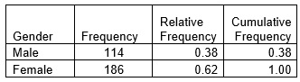

**Frequency table of Gender**

Besides the frequency table, a bar chart or a pie chart is used to present the data.

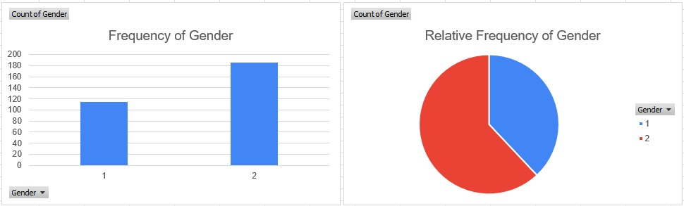

**Bar chart and Pie chart**

Data for one statistical variable appears as one column in a data set. Frequency is the number of times a particular value appears in the column. We use a frequency table to summarise the data, where all possible values in the data are listed in the first column and the corresponding frequencies in the second column.

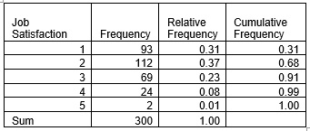

**Frequency table of Job Satisfaction Score befor Training**

Using mathematical notation, the frequency table can be written as follows:

p(Job Satisfaction=1)=0.31 $\hspace{2cm}$ p(Job Satisfaction=2)=0.37  
p(Job Satisfaction≤3)=0.91 $\hspace{2cm}$ p(2≤Job Satisfaction≤3)=0.60

The last formula above indicates that the proportion for the variable Job Satisfaction to assume a value between 2 and 3 is 60%.

## 7.2.2 Diagrams

### 7.2.2.1 Column charts, bar charts, and pie charts

[figure not shown]

In the charts above, we see that Job Satisfaction can assume five different values. The most frequent value is 2, followed by 1, while the less frequent values are 3, 4, and 5. While the bar chart emphasises the absolute frequencies, the pie chart is more suitable for showing the relative frequencies.

### 7.2.2.2 Histogram

For numerical variables, we need to group the data first and then create the frequency table. The reason is that, in principle, no two values of a continuous variable may be identical, and hence the frequency would always have value 1 for all distinct values.

For the variable **Age**, we have:

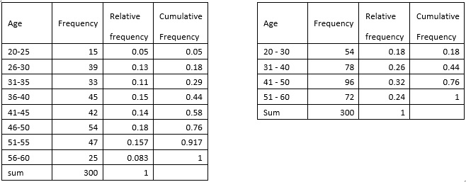

**Frequency tables of Age with two different groupings**

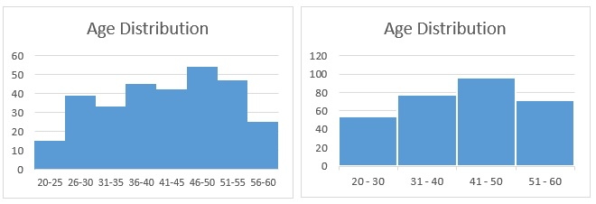

**Figure 2 Histogram of Age with two different groupings**

**Choice of the number of bins and its impact**

A histogram with peaks in the middle and lower values at both ends indicates that the majority of the data is concentrated in the middle, while the extremes have fewer observations. Conversely, a histogram that is very flat over a large range suggests that the data are spread out rather than concentrated within a specific range. If a histogram has a tall peak in the middle and the data range is narrow, it implies that the data are tightly concentrated around the middle.

The shape of a histogram describes how the data of a statistical variable are distributed. In our daily lives, it works quite well to use two categorical variables {tall, short} and {thin, fat} to communicate the shape of a human figure. Similarly, we can use two numbers to describe the distribution (figure) of a statistical variable. The first number is the sample average that describes the center of the data, and the second number is the standard deviation that describes the dispersion of the data from the center. The numbers that characterise the distribution of statistical variables are called numerical measures.

## 7.2.3 Numerical measures

### 7.2.3.1 Measures of central location

For given data $x_{1},x_{2},x_{3},\ldots,x_{N}$, we have

**Sample Average:**

$\overline{x} = \frac{x_{1} + x_{1} + \ldots{+ x}_{N}}{N} = \frac{1}{N}{\sum_{i = 1}^{N}x}_{i}$

**Sample Median:**

Order the data increasingly: $x_{(1)} \leq x_{(2)} \leq x_{(3)} \leq \ldots \leq x_{(N)}$, median of this data set is the value of the data element in the middle, i.e. 50% percent of the data are less than the median and 50% are larger than the median.

$x_{\text{Median}} = x_{\big(\frac{N + 1}{2}\big)}$ for odd $N$.

$x_{\text{Median}} = \frac{x_{\big(\frac{N}{2}\big)} + x_{\big(\frac{N}{2}+1\big)}}{2}$ for even $N$

For a small group of kindergarten children, the average age provides useful information about the ages of the group. For the same group plus a senior nursery teacher, the average age does not provide useful information. In this case, the sample median is a more appropriate measure.

**Percentiles**

Beside the 50 percentile, many other percentiles are also used. For example, if we read in the news that 20% of households in Australia earned less than $25{,}000 a year, then $25{,}000 is the 20th percentile of household income in Australia.

We call the 25th percentile the lower quartile and the 75th percentile the upper quartile. For the lower quartile $x_{[0.25]}$, we have at least 25% of the data less than or equal to $x_{[0.25]}$ and at least 75% of the data greater than or equal to $x_{[0.25]}$. With two different percentiles, we can easily determine what percentage of the data lie between them. For example, between the lower quartile $x_{[0.25]}$ and the upper quartile $x_{[0.75]}$, there are at least 50% of the data. Formally,

$p\left( x_{\lbrack 0.25\rbrack} \leq x \leq x_{\lbrack 0.75\rbrack} \right) = 50\%$

This equation says that 50% of the data $x$ lie within the interval $\left\lbrack x_{\lbrack 0.25\rbrack},x_{\lbrack 0.75\rbrack} \right\rbrack$. Similarly, we have

$p\left( x_{\lbrack 0.16\rbrack} \leq x \leq x_{\lbrack 0.84\rbrack} \right) = 68\%$.

$p\left( x_{\lbrack 0.025\rbrack} \leq x \leq x_{\lbrack 0.975\rbrack} \right) = 95\%$.

The last equation says that after removing 2.5% at each end, 95% remains in the middle.

**Mode:** the value of the data point with the highest frequency for categorical data. For numerical data, the mode is the interval (group) with the highest frequency.

### 7.2.3.2 Measures of variation (dispersion):

**Sample variance**

$s_{X}^{2} = \frac{\left( x_{1} - \overline{x} \right)^{2} + \left( x_{2} - \overline{x} \right)^{2} + \ldots + \left( x_{N} - \overline{x} \right)^{2}}{N - 1}$ =$\frac{1}{N - 1}\sum_{i = 1}^{N}{(x_{i}} - \overline{x})^{2}$

The magnitude of variance is measured in squared units of $X$, which makes it difficult to interpret. Therefore, people prefer to use the square root of variance, called the standard deviation, as a measure of variation.

**Sample standard deviation** $\text{SD}(x) = s_{X} = \sqrt{s_{X}^{2}}$

When the sample standard deviation is larger, the data points are spread farther away from the centre, while when it is smaller, the data points are located closer to the centre. Other measures of variation are range and interquartile range.

**Interquartile range** $IQR = x_{[0.75]} - x_{[0.25]}$

The interquartile range gives the interval containing the middle 50% of the data.

**Range** $L = \ x_{\text{MAX}} - x_{\text{MIN}}$

## 7.2.4 Rules of 68, 95, and 99.7

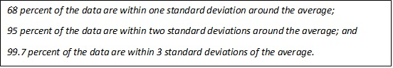

The 68, 95, and 99.7 rules help us use the sample average and sample standard deviation to gauge the distribution of data.

Using *Salary* as an example, with $\overline{\text{Salary}} = 52.5$ and $\text{SD}\left( \text{Salary} \right) = 9.3$, the rules tell us that roughly 68% of employees (or salary observations) earn between $43.2K and $61.8K, and roughly 95% earn between $33.9K and $71.1K. Does this statement sound like magic?

In mathematical notation, the statement can be written as follows:

$p(52.5 - 9.3 \leq Salary \leq 52.5 + 9.3) = p(43.2 \leq Salary \leq 61.8) \approx 68\%$

$p(52.5 - 2 \times 9.3 \leq Salary \leq 52.5 + 2 \times 9.3) = p(33.9 \leq Salary \leq 71.1) \approx 95\%$

The rules apply well when the data have a bell-shaped distribution, that is, when the histogram is roughly symmetric and has one peak.

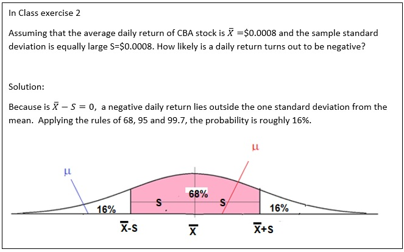

**Summary**: Descriptive statistics is all about describing (1) the possible values of the variable and (2) how frequent each value or each group of values appear in the data. Statistician used to call these two aspects by “**distribution of the variable**” or distribution of the data.

In frequency tables all possible values are in the first column and frequencies in the second column. In a bar chart all possible values are on the horizontal axis and the frequencies are represented by the bars. The sample average, median, and mode give the centre of the distribution, and the standard deviation can be used to describe how concentrated the data are around the centre (the 68, 95, and 99.7 rules). Quartiles and the interquartile range can also be used to describe the location and the concentration of the data.

The following [video clip shows how to create frequency tables and charts using Excel](https://www.youtube.com/embed/3QdiZJNqgzc?si=GeYQ8GPI6-O4e2SR).

[video not shown]

## 7.2.5 Descriptive statistics for two statistical variables

### 7.2.5.1 Two categorical variables

### Two-way tables for two categorical variables

As in the univariate case, we also use frequency tables to summarise two statistical variables. Since we have two variables, the frequencies for each pair of values are organised in a two-way table.

[output not shown]

[Create a two-way table using Excel](https://www.youtube.com/embed/FjXwKc6g6Dk)

[video not shown]

### Clustered column charts

The two-way frequency table above can be presented as a clustered column chart.

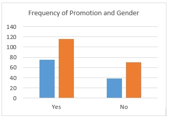

**Clustered column chart**

In each cluster, the columns show the gender frequencies within the promoted and not promoted groups, respectively.

### 7.2.5.2 One categorical variable one numerical variable

When we relate a numerical variable and a categorical variable, the categorical variable separates the numerical variable into groups corresponding to the values of the categorical variable. The main focus is comparing the numerical variable across different groups.

### Two-way table for categorical and numerical variables

Similar to the two-categorical-variable case, two-way frequency tables can be used to summarise one categorical variable and one numerical variable, where the numerical variable has to be grouped before creating the two-way frequency table.

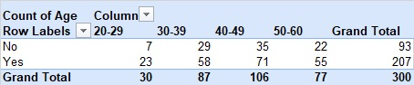

**Two-way table for Age and Promotion**

### Comparative box plots

Although clustered column charts can be utilised to present the two-way table, comparative box plots are more often used to present the distribution of a numerical variable across many groups.

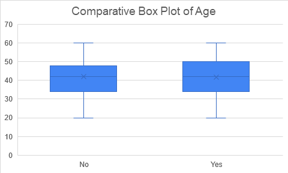

A box plot summarises a numerical variable using six numerical measures: the minimum, the 25th percentile, the median, the average, the 75th percentile, and the maximum. The line at the lowest end is the minimum of the data, the lower side of the box is the 25th percentile, the line in the middle of the box is the median, the cross in the middle of the box is the average, the upper side of the box is the 75th percentile, and the line at the upper end is the maximum of the data.

Comparing the two box plots, we see that the respective minimum and maximum are the same in the two groups. The 25th percentile and the median are the same in the two groups, while the 75th percentile in the promoted group is slightly higher than that in the not promoted group.

### 7.2.5.3 Two numerical variables

### Two-way frequency table

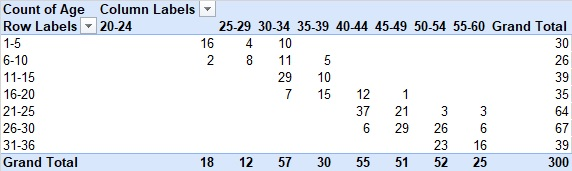

**Two-way frequency table of Age and Years of Experience**

### Covariance and correlation coefficient

**Sample covariance** $s_{\text{XY}} = \frac{\sum_{i = 1}^{N}{\left( x_{i} - \overline{x} \right)\left( y_{i} - \overline{y} \right)}}{N - 1}$

If the sample covariance is positive, this implies the two variables move in the same direction. If the sample covariance is negative, these two variables move in opposite directions. However, the magnitude of the covariance depends on the units in which the variables are measured. It cannot reflect the strength of the relationship. To remove the effect of the measuring units, statisticians normalise the sample covariance by dividing it by the sample standard deviations. This ratio is called the sample correlation coefficient, which is independent of the measuring units:

**Sample correlation coefficient** $\rho_{\text{XY}} = \frac{s_{\text{XY}}}{s_{X}s_{Y}} = \frac{\sum_{i = 1}^{N}{\left( x_{i} - \overline{x} \right)\left( y_{i} - \overline{y} \right)}}{\sqrt{\sum_{i = 1}^{N}{\left( x_{i} - \overline{x} \right)\left( x_{i} - \overline{x} \right)\sum_{i = 1}^{N}{\left( y_{i} - \overline{y} \right)\left( y_{i} - \overline{y} \right)}}}}$

The sample correlation coefficients are always between -1 and 1. If the correlation coefficient is close to 1, the two variables have strong positive linear relation, if it is close to -1, the two variables have a strong negative linear relation. If it is close to 0, there is no linear relationship between the two variables.

### Scatter plot

Scatter plots are often used to illustrate the relationship between two numerical variables. For two numerical variables, each data pair is one point in the coordinate system representing the two variables.

The scatter plot is a useful visual tool for examining the relationship between statistical variables. If the two variables move in the same direction, the data cloud will scatter around an upward-sloping line. If the two variables move in opposite directions, the data cloud will scatter around a downward-sloping line. [How to use Excel to create a scatter plot with a trend line?](https://www.youtube.com/watch?v=5JdSjiDZwrw)

The following graph is a scatter plot of Age and Years of Experience.

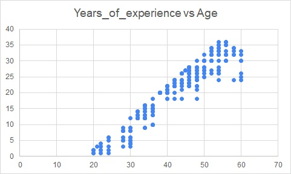

**Scatter plot**

### Overview of types of variables and the used descriptive tools

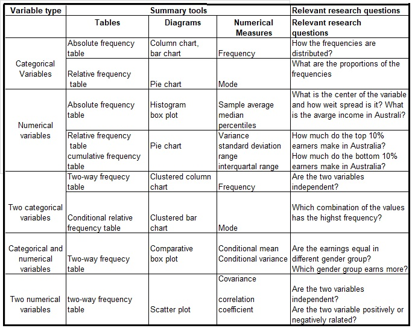

**Summary of descriptive tools and variable types**

## 7.2.6 Examples of applications:

[Statistics can be used to predict election results](https://www.theaustralian.com.au/topics/newspoll) In this case, statistics is used to answer questions such as how can we predict the outcome of the election? How much data are sufficient to make a reliable prediction? We will be able to carry out these tasks in week 9.

[Study of financial markets](https://www2.asx.com.au/investors/investment-tools-and-resources/online-courses) In this case, statistics is used to forecast the future returns of stocks. In Week 11, we will learn regression techniques, which are among the most commonly used statistical methods for forecasting.

[Presentation of data](https://ahaslides.com/blog/10-methods-of-data-presentation/) These are some of the most commonly used techniques in business data reporting. We will learn these techniques in Weeks 7 and 8.

[Weather forecast](https://weather.com/weather/today/l/-33.87,151.21?par=google)

### Summary

- Definition of statistics
- Skill (1): using Google Forms for online data collection
- Understanding characteristics of statistical variables
- Skill (2): creating frequency tables, bar charts, and pie charts using Excel
- Skill (3): creating frequency tables and charts for two statistical variables
- Application of rules of 68, 95, and 99.7 to comprehend statistical variables

## Review questions

1. What is statistics?
2. How would you characterise a statistical variable?
3. Where can we apply statistics in business?
4. How do you create a Google Form for online data collection?
5. Why do we classify statistical variables as categorical and numerical?

[interactive chart not shown]